# PSY6422 - Data Analysis and Visualisation

Fiona McGavin

20/05/2020

# Investigating the relationship between traits in characters in the Lord of the Rings.

## Project aims

Investigate the realtionship between two traits in the data set and draw conclusions. Specifically, investigate the relationship between the traits ‘race’ and ‘gender’. I aim to produce three visulisations; one visulisation to best represent each trait and combined visulisation including both ‘gender’ and ‘race’ data.

## Data origins

All data was publicly available via github https://github.com/tianyigu/Lord_of_the_ring_project/blob/master/LOTR_code/lotr_demograph_scripy/lotr.csv

The raw data was collected using a web scraper which autonomously collected data from the Lord of the Rings wiki (http://lotr.wikia.com) and the Lord of the Rings uk fan page (http://www.ageofthering.com).

For additonal info see link https://nycdatascience.com/blog/student-works/journey-to-middle-earth-webscraping-the-lord-of-the-ring/

## Data preparation

Many of the characters in the data set were labelled innapropriately - as this project examines only two specific catagories (race and gender) only two catagories were underwent preprocessing steps.

Please refer to descriptions of figures 1b, 2b & 3 for more details.

## Raw data

```r
#load libraries

library(tm)
```

```r
library(knitr)
library(ggimage)
library(igraph)
library(ggraph)
library(dplyr)
library(forcats)
library(ggplot2)

#set path

setwd("~/R/R_Data/Data_VisTask/Raw")

#Read data

characters <- read.csv("C:\\Users\\Fiona\\Documents\\R\\R_Data\\Data_VisTask\\Raw\\lotr.csv")
```

```r
#View data/data summary

colnames(characters)
```

```
## [1] "birth"  "death"  "gender" "hair"   "height" "name"   "race"   "realm"
## [9] "spouse"
```

```r
dim(characters)
```

```
## [1] 911   9
```

```r
head(characters,n=10)
```

```
##          birth               death gender                            hair
## 1       Unknow              Unknow Female                          Unknow
## 2      TA 2978 February 26,, ,3019   Male Dark (book) Light brown (movie)
## 3      Unknown       March,, ,3019   Male                          Unknow
## 4   TA 280,[1]          TA 515,[2]   Male                          Unknow
## 5       Unknow              Unknow   Male                          Unknow
## 6  SA 2709,[1]         SA 2962,[1]   Male                          Unknow
## 7      Unknown             Unknown   Male                          Unknow
## 8        YT, ?              FA 455   Male                          Golden
## 9       Unknow              Unknow Unknow                          Unknow
## 10     SA 3219 SA 3440, (aged 221)   Male                          Unknow
##    height                   name   race    realm       spouse
## 1  Unknow                 Adanel    Men   Unknow      Belemir
## 2  Unknow                Boromir    Men   Unknow       Unknow
## 3  Unknow                 Lagduf   Orcs   Unknow       Unknow
## 4  Unknow                 Tarcil    Men    Arnor Unnamed wife
## 5  Unknow Fire-drake of Gondolin Dragon   Unknow       Unknow
## 6  Unknow         Ar-AdÃ»nakhÃ´r    Men NÃºmenor Unnamed wife
## 7  Unknow                 Annael  Elves   Unknow      Unknown
## 8  Unknow                 Angrod  Elves   Unknow   EldalÃ³tÃ«
## 9  Unknow                 Angrim Unknow   Unknow       Unknow
## 10 Unknow               AnÃ¡rion    Men   Gondor Unnamed wife
```

```r
tail(characters,n=10)
```

```
##                                     birth           death gender   hair height
## 902                           TA 1330,[1]     TA 1540,[2]   Male Unknow Unknow
## 903           Before the creation of Arda         Unknown   Male Unknow Unknow
## 904                           TA 2827,[1]     TA 2932,[1]   Male Unknow Unknow
## 905                                Unknow          Unknow Unknow Unknow Unknow
## 906                                Unknow          Unknow Unknow Unknow Unknow
## 907                     Mid ,First Age, ?          FA 495 Female Unknow Unknow
## 908                                Unknow          Unknow Unknow Unknow Unknow
## 909 YT, ? during the ,Noontide of Valinor      FA 455,[2]   Male Golden Unknow
## 910                           TA 2917,[1]     TA 3010,[1]   Male Unknow Unknow
## 911                       Before ,TA 1944 Late ,Third Age   Male Unknow Unknow
##           name        race  realm                                  spouse
## 902    Aldamir         Men Gondor                            Unnamed wife
## 903     Alatar Ainur,Maiar Unknow                                    None
## 904    Aglahad         Men Unknow                            Unnamed wife
## 905      Aghan      Unknow Unknow                                  Unknow
## 906    Agathor      Unknow Unknow                                  Unknow
## 907      Aerin         Men Unknow                                  Brodda
## 908   Aerandir      Unknow Unknow                                  Unknow
## 909     Aegnor       Elves Unknow Loved ,Andreth,, but remained unmarried
## 910 Adrahil II         Men Unknow                            Unnamed wife
## 911  Adrahil I         Men Unknow                                 Unknown
```

```r
summary(characters)
```

```
##     birth              death              gender              hair
##  Length:911         Length:911         Length:911         Length:911
##  Class :character   Class :character   Class :character   Class :character
##  Mode  :character   Mode  :character   Mode  :character   Mode  :character
##     height              name               race              realm
##  Length:911         Length:911         Length:911         Length:911
##  Class :character   Class :character   Class :character   Class :character
##  Mode  :character   Mode  :character   Mode  :character   Mode  :character
##     spouse
##  Length:911
##  Class :character
##  Mode  :character
```

## View data/data structure

This data set is made up of 911 rows (characters) and consists of nine variables; ‘birth’, ‘gender’, ‘hair colour’, ‘height’ ‘name’, ‘race’, ‘realm’ and ‘marital status’.

For this project two traits will be examined; race and gender. Other traits/catagories in the data set required a lot of preprocessing (birth & death) before the data is workable, so were not the first choice of variables. Alternatively, some traits/catagories in the data set are not especially meaningful and unliklely to yeild meanigful analysis (hair colour and height) so were not chosen for this project.

## Figure 1a

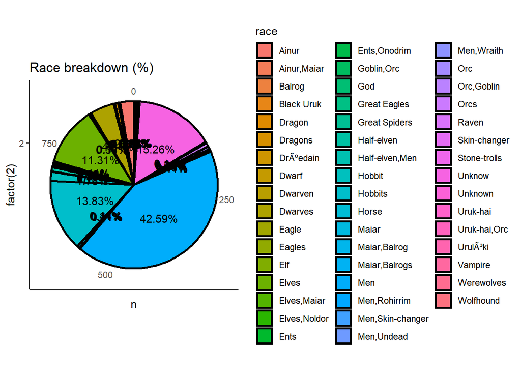

```r
#Race breakdown - unfiltered data (Figure 1a)

characters %>%
  filter(race!="") %>% # filter variable
    count(race) %>% #count variable
      mutate(Percentage=paste0(round(n/sum(n)*100, 2),"%")) %>% # add percentages

  ggplot(aes(x=factor(2), y=n, fill = race)) +
  geom_bar(stat="identity", width=1, size=1, color="black") +
  coord_polar(theta="y") +
  labs(title="Race breakdown (%)") +
  theme(plot.title = element_text(hjust = 0.5)) + # create graph - pie chart & add colour

theme_classic() +
geom_text(aes(label=Percentage),
          position=position_stack(vjust = 0.5)) # add theme and labels
```

This graph has number of issues that needs to be addressed:

1. There are too many catagories to display in this chart, this needs be reduced to top ten highest percentages
2. There percentages are unreadable as they are overlapping in many instances.
3. The chart has unwanted axis with labels.
4. Ideally the heading should be centralised.
5. Many of the catagories overlap i.e. ‘Orc’ is equivalent to ‘Orcs’.
6. Unknown data values

## Figure 1b

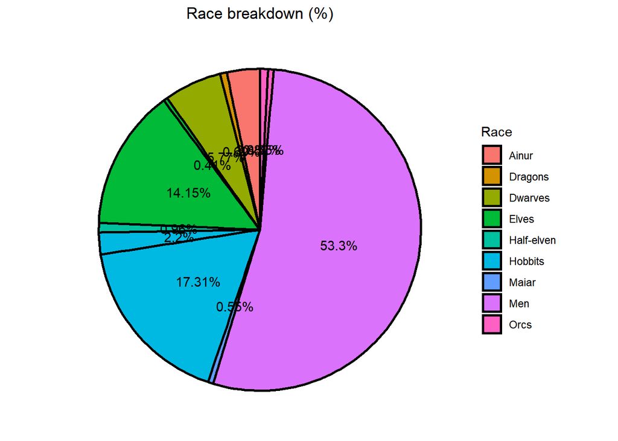

```r
#Race breakdown - filtered data (figure 1b)

characters %>%
  filter(race!="",race!="Unknown",race!="Unknow") %>% # filter variable
    count(race) %>% # count variable
      arrange(desc(n)) %>% # arrange descending order
        slice(1:12) %>% # reduce number of races shown on pie chart
  mutate(Percentage=paste0(round(n/sum(n)*100, 2),"%")) %>% # add percentage

  mutate(race=fct_recode(race, "Hobbits"="Hobbit")) %>%
  mutate(race=fct_recode(race, "Dwarves"="Dwarf")) %>%
  mutate(race=fct_recode(race, "Dwarves"="Dwarven")) %>%
  mutate(race=fct_recode(race, "Orcs"="Orc")) %>%
  mutate(race=fct_recode(race, "Elves"="Elf")) %>% #recode data - pre-processing step.

    ggplot(aes(x="", y=n, fill = race)) +
    geom_bar(stat="identity", width=1, size=1, color="black") +
    coord_polar(theta="y") +
    labs(title="Race breakdown (%)") + # create graph - pie chart

    theme_classic() +
    theme(plot.title = element_text(hjust = 0.5),
        axis.text = element_blank(),
        axis.line = element_blank(),
        axis.title = element_blank(),
        axis.ticks = element_blank())+
    geom_text(aes(label=Percentage),
          position=position_stack(vjust = 0.5))+
    labs(x = "", fill = "Race") # remove axis and axis labels, format text, assign theme & title legend
```

This graph represents a break down of the most common races featuring in the dataset (the lord of the rings wikki). There was a number of preprocessing steps that were undertaken during the construction of this visulisation:

The original data set was aquired via a data scraping method meaning some of the data in the data set needed recoded into more worakable format. For example ‘Dwarf’ and ‘Dwarven’ were recoded as ‘Dwarves’, proir to this step, each of these words would represent 3 seperate catagories and thus inflate the number of ‘races’ in the data set.Therefore, following the recoding of the data the graph depicts a more accurate representattion of the breakdonw of the most common races within the data set.

Looking at the graph it is apparant that ‘Men’ represent majority characters in data set at around 50%. The smallest catagory is difficult to determine when looking at the graph. Additional changes need to made to this visulisation to ensure the readibilty of the percentage labels (perhaphs placing them around the circumferance).Furthermore, there were simply too many catagories to display on this graph. The data was first arranged in descending order and then sliced to represent only the highest percentages.

## Figure 2a

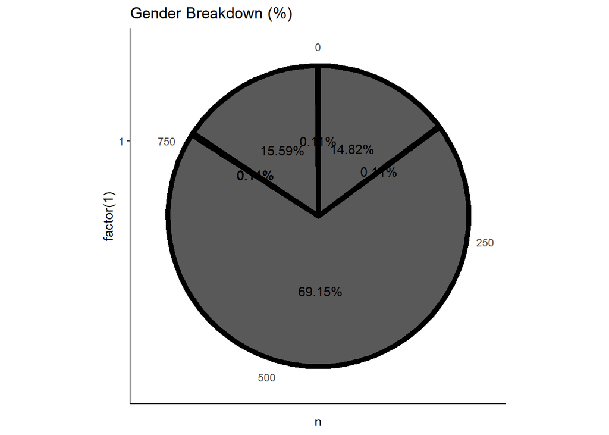

```r
#Gender breakdown - unfiltered data (figure 2a)

characters %>%
  count(gender) %>% # count variable
    mutate(Percentage=paste0(round(n/sum(n)*100, 2), "%")) %>% # add percentages

ggplot(aes(x=factor(1), y=n,)) +
geom_bar(stat="identity", width=2, size=2, color="black") +
coord_polar(theta="y") +
labs(title="Gender Breakdown (%)") + # create graph - pie chart

theme_classic() +
geom_text(aes(label=Percentage),
            position=position_stack(vjust = 0.5)) # add theme and labels
```

This graph has number of issues that needs to be addressed:

1. There is no legend to determine what percetages refer to what gender?
2. There is more than two percentages? There should only be two, to represent male and female?
3. The pie chart has visble and uncessary axis.
4. Colour would be beneficial as well as a centralised heading.

## Figure 2b

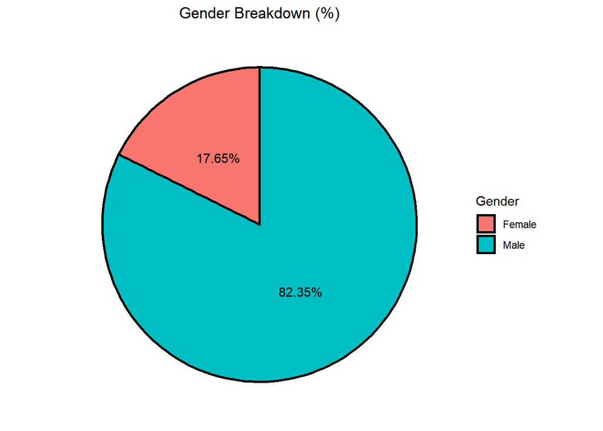

```r
#Gender visulisation - filtered data (figure 2b)

characters %>%
  filter(gender!= "Unknown", gender!= "Unknow", !gender %in% c("","male","Males", "Most likely male")) %>% # filter gender 'Male' and 'unknown' & group varaibles
    count(gender) %>% # count variable
      mutate(Percentage=paste0(round(n/sum(n)*100, 2), "%")) %>% # add percentages

  ggplot(aes(x=factor(2), y=n, fill=gender)) +
  geom_bar(stat="identity", width=1, size=1, color="black") +
  coord_polar(theta="y") + # create graph - pie chart

labs(title="Gender Breakdown (%)") +
theme_classic() +
theme(plot.title = element_text(hjust = 0.5),
      axis.text = element_blank(),
      axis.line = element_blank(),
      axis.title = element_blank(),
      axis.ticks = element_blank())+ # remove axis and axis labels, format text & assign theme
geom_text(aes(label=Percentage),
          position=position_stack(vjust = 0.5))+
labs(x = "", fill = "Gender") # capatalise legend title.
```

This graph describes the gender breakdown of the characters in the data set, specifically that 80% of the characters in the data set can be described as male.

Adressing issues with the previous graph, the unwanted axis and axis heading were hidden using a extra bit of code. Furthermore, the gender catagories are now dilineated by colour as shown via the legend.

## Figure 3

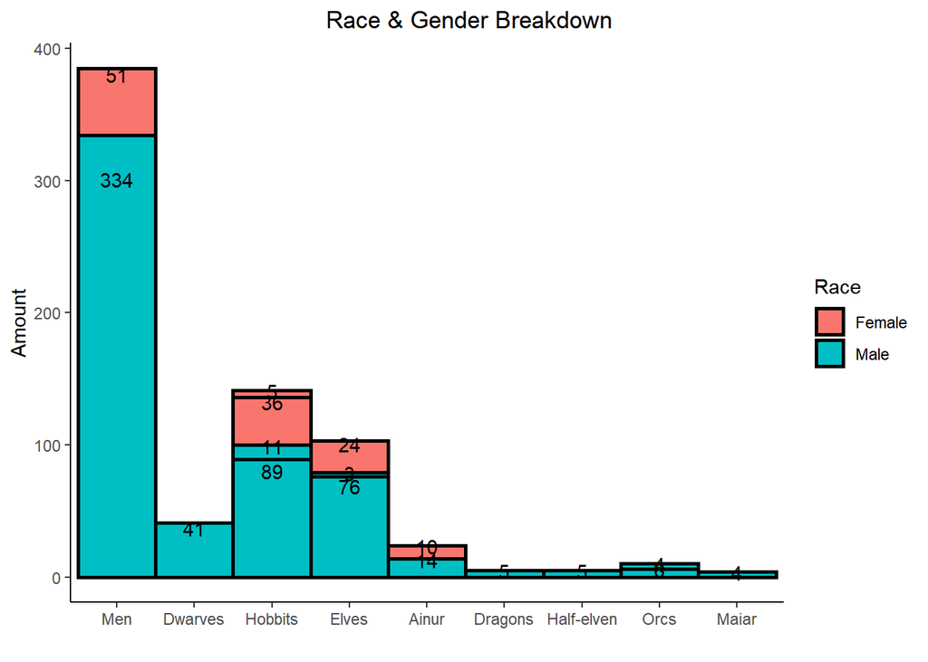

```r
#Race and Gender combined  bar chart (figure 3)

characters %>%
  filter(race!="") %>%
    filter(gender!= "Unknown", gender!= "Unknow", !gender %in% c("","male","Males", "Most likely male")) %>% #         filter gender 'Male' & group varaibles
      count(race, gender) %>% # count variables
        arrange(desc(n)) %>% # arrange descending order
          slice(1:17) %>% # slice variables


  mutate(race=fct_recode(race, "Hobbits"="Hobbit")) %>%
  mutate(race=fct_recode(race, "Dwarves"="Dwarf")) %>%
  mutate(race=fct_recode(race, "Dwarves"="Dwarven")) %>%
  mutate(race=fct_recode(race, "Orcs"="Orc")) %>%
  mutate(race=fct_recode(race, "Elves"="Elf")) %>% # recode races


  ggplot(aes(x=reorder(race, -n), y=n)) +
  geom_bar(stat="identity", aes(fill=gender), width=1, size=1, color="black") +
  geom_text(aes(label=n, group=gender), position=position_stack(vjust=0.9)) +
  labs(x="Race", y="Amount", title="Race & Gender Breakdown") + # create graph - bar chart

  theme_classic() +
  labs(x = "", font.lab = 2, fill = "Race") +
  theme(plot.title = element_text(hjust = 0.6)) # add theme & format text
```

This graph represent the gender breakdonw by race in the data set. The graph demonstartes that there is greater number of female characters in more common races compared to less common races. Futhermore all races have a signficantly greater percentage of males compared to females.

It is hardly surpsing that Dwarves have are entirely classified as male, this is a common trope in the fantasty genre.In lord of the ring lore, female dwarves upon marriage join their husbands families, and as such are not featured in geaniologies [http://tolkiengateway.net/wiki/Dwarf-women] [https://lotr.fandom.com/wiki/Dwarves].

# Summary

Whislt these graphs highlight some interesting trends, this project has looked at only two traits out of multiple that exist in the data set. Going forward, analysis of additional traits may alter the interpretation of this data and provide some context to the trends observed. Furthermore, whilst interesting, this data is largely superficial. To make this experimental question more meaningful, a sentiment analysis surrounding the language and terminolgy used to describe different races and genders may yeild more meaningful conclusion. Alternatively, analysising the dialogue of specific characters may provide a greater insight into specific traits affiliated with particular genders and races within the book series.

# Final Comments

This project allowed me to put basiccoding skills into practice using data which interested me. I can now produce reasonable graphs and manipulate data to a small extent, which is something I was unable to do before.

This project threw many challenges at me, which I was able to resolve for the most part. That being said, the readabilty of my graphs is poor especially in figure 1b. This is something I hope to build upon in future work. Furthermore, I particularly struggled adding the finishing touches to my graphs, including changing text fonts, chaging positions of headings/label and adding colours/themes. In future work, I would like to focus on this especially.